# Analytics Edge: Unit 1 - An Analytical Detective

Sulman Khan

October 24, 2018

## Background Information on the Dataset

Crime is an international concern, but it is documented and handled in very different ways in different countries. In the United States, violent crimes and property crimes are recorded by the Federal Bureau of Investigation (FBI). Additionally, each city documents crime, and some cities release data regarding crime rates. The city of Chicago, Illinois releases crime data from 2001 onward online.

Chicago is the third most populous city in the United States, with a population of over 2.7 million people. The city of Chicago is shown in the map below, with the state of Illinois highlighted in red.

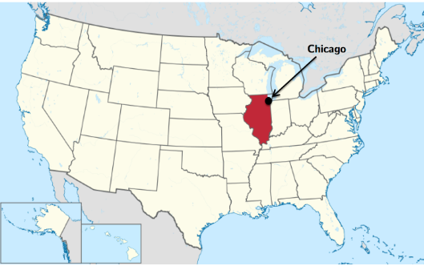

There are two main types of crimes: violent crimes, and property crimes. In this problem, we’ll focus on one specific type of property crime, called “motor vehicle theft” (sometimes referred to as grand theft auto). This is the act of stealing, or attempting to steal, a car. In this problem, we’ll use some basic data analysis in R to understand the motor vehicle thefts in Chicago.

Please download the file mvtWeek1.csv. for this problem (do not open this file in any spreadsheet software before completing this problem because it might change the format of the Date field). Here is a list of descriptions of the variables:

- **ID**: a unique identifier for each observation
- **Date**: the date the crime occurred
- **LocationDescription**: the location where the crime occurred
- **Arrest**: whether or not an arrest was made for the crime (TRUE if an arrest was made, and FALSE if an arrest was not made) Domestic: whether or not the crime was a domestic crime, meaning that it was committed against a family member (TRUE if it was domestic, and FALSE if it was not domestic) Beat: the area, or “beat” in which the crime occurred. This is the smallest regional division defined by the Chicago police department. District: the police district in which the crime occured. Each district is composed of many beats, and are defined by the Chicago Police Department.
- **CommunityArea**: the community area in which the crime occurred. Since the 1920s, Chicago has been divided into what are called “community areas”, of which there are now 77. The community areas were devised in an attempt to create socially homogeneous regions.
- **Year**: the year in which the crime occurred.
- **Latitude**: the latitude of the location at which the crime occurred.
- **Longitude**: the longitude of the location at which the crime occurred.

## R Exercises

Read the dataset mvtWeek1.csv. into R, using the read.csv function, and call the data frame “mvt”. Remember to navigate to the directory on your computer containing the file mvtWeek1.csv first. It may take a few minutes to read in the data, since it is pretty large. Then, use the str and summary functions to answer the following questions.

```r
mvt = read.csv("mvtWeek1.csv")
```

### How many rows of data (observations) are in this dataset?

```r
str(mvt)
```

```
## 'data.frame':    191641 obs. of  11 variables:
##  $ ID                 : int  8951354 8951141 8952745 8952223 8951608 8950793 8950760 8951611 8951802 8950706 ...
##  $ Date               : Factor w/ 131680 levels "1/1/01 0:01",..: 42824 42823 42823 42823 42822 42821 42820 42819 42817 42816 ...
##  $ LocationDescription: Factor w/ 78 levels "ABANDONED BUILDING",..: 72 72 62 72 72 72 72 72 72 72 ...
##  $ Arrest             : logi  FALSE FALSE FALSE FALSE FALSE TRUE ...
##  $ Domestic           : logi  FALSE FALSE FALSE FALSE FALSE FALSE ...
##  $ Beat               : int  623 1213 1622 724 211 2521 423 231 1021 1215 ...
##  $ District           : int  6 12 16 7 2 25 4 2 10 12 ...
##  $ CommunityArea      : int  69 24 11 67 35 19 48 40 29 24 ...
##  $ Year               : int  2012 2012 2012 2012 2012 2012 2012 2012 2012 2012 ...
##  $ Latitude           : num  41.8 41.9 42 41.8 41.8 ...
##  $ Longitude          : num  -87.6 -87.7 -87.8 -87.7 -87.6 ...
```

**Explanation**: If you type str(mvt) in the R console, the first row of output says that this is a data frame with 191,641 observations.

### How many variables are in this dataset?

```r
str(mvt)
```

```
## 'data.frame':    191641 obs. of  11 variables:
##  $ ID                 : int  8951354 8951141 8952745 8952223 8951608 8950793 8950760 8951611 8951802 8950706 ...
##  $ Date               : Factor w/ 131680 levels "1/1/01 0:01",..: 42824 42823 42823 42823 42822 42821 42820 42819 42817 42816 ...
##  $ LocationDescription: Factor w/ 78 levels "ABANDONED BUILDING",..: 72 72 62 72 72 72 72 72 72 72 ...
##  $ Arrest             : logi  FALSE FALSE FALSE FALSE FALSE TRUE ...
##  $ Domestic           : logi  FALSE FALSE FALSE FALSE FALSE FALSE ...
##  $ Beat               : int  623 1213 1622 724 211 2521 423 231 1021 1215 ...
##  $ District           : int  6 12 16 7 2 25 4 2 10 12 ...
##  $ CommunityArea      : int  69 24 11 67 35 19 48 40 29 24 ...
##  $ Year               : int  2012 2012 2012 2012 2012 2012 2012 2012 2012 2012 ...
##  $ Latitude           : num  41.8 41.9 42 41.8 41.8 ...
##  $ Longitude          : num  -87.6 -87.7 -87.8 -87.7 -87.6 ...
```

**Explanation**: If you type str(mvt) in the R console, the first row of output says that this is a data frame with 11 variables.

### Using the “max” function, what is the maximum value of the variable “ID”?

```r
max(mvt$ID)
```

```
## [1] 9181151
```

**Explanation**: You can compute the maximum value of the ID variable with max(mvt$ID).

### What is the minimum value of the variable “Beat”?

```r
summary(mvt)
```

```
##        ID                      Date                            LocationDescription   Arrest         Domestic            Beat         District
##  Min.   :1310022   5/16/08 0:00  :    11   STREET                        :156564   Mode :logical   Mode :logical   Min.   : 111   Min.   : 1.00
##  1st Qu.:2832144   10/17/01 22:00:    10   PARKING LOT/GARAGE(NON.RESID.): 14852   FALSE:176105    FALSE:191226    1st Qu.: 722   1st Qu.: 6.00
##  Median :4762956   4/13/04 21:00 :    10   OTHER                         :  4573   TRUE :15536     TRUE :415       Median :1121   Median :10.00
##  Mean   :4968629   9/17/05 22:00 :    10   ALLEY                         :  2308                                   Mean   :1259   Mean   :11.82
##  3rd Qu.:7201878   10/12/01 22:00:     9   GAS STATION                   :  2111                                   3rd Qu.:1733   3rd Qu.:17.00
##  Max.   :9181151   10/13/01 22:00:     9   DRIVEWAY - RESIDENTIAL        :  1675                                   Max.   :2535   Max.   :31.00
##                    (Other)       :191582   (Other)                       :  9558                                                  NA's   :43056
##  CommunityArea        Year         Latitude       Longitude
##  Min.   : 0      Min.   :2001   Min.   :41.64   Min.   :-87.93
##  1st Qu.:22      1st Qu.:2003   1st Qu.:41.77   1st Qu.:-87.72
##  Median :32      Median :2006   Median :41.85   Median :-87.68
##  Mean   :38      Mean   :2006   Mean   :41.84   Mean   :-87.68
##  3rd Qu.:60      3rd Qu.:2009   3rd Qu.:41.92   3rd Qu.:-87.64
##  Max.   :77      Max.   :2012   Max.   :42.02   Max.   :-87.52
##  NA's   :24616                  NA's   :2276    NA's   :2276
```

```r
min(mvt$Beat)
```

```
## [1] 111
```

**Explanation**: If you type summary(mvt) in your R console, you can see the summary statistics for each variable. This shows that the minimum value of Beat is 111. Alternatively, you could use the min function by typing min(mvt$Beat).

### How many observations have value TRUE in the Arrest variable (this is the number of crimes for which an arrest was made)?

```r
summary(mvt)
```

```
##        ID                      Date                            LocationDescription   Arrest         Domestic            Beat         District
##  Min.   :1310022   5/16/08 0:00  :    11   STREET                        :156564   Mode :logical   Mode :logical   Min.   : 111   Min.   : 1.00
##  1st Qu.:2832144   10/17/01 22:00:    10   PARKING LOT/GARAGE(NON.RESID.): 14852   FALSE:176105    FALSE:191226    1st Qu.: 722   1st Qu.: 6.00
##  Median :4762956   4/13/04 21:00 :    10   OTHER                         :  4573   TRUE :15536     TRUE :415       Median :1121   Median :10.00
##  Mean   :4968629   9/17/05 22:00 :    10   ALLEY                         :  2308                                   Mean   :1259   Mean   :11.82
##  3rd Qu.:7201878   10/12/01 22:00:     9   GAS STATION                   :  2111                                   3rd Qu.:1733   3rd Qu.:17.00
##  Max.   :9181151   10/13/01 22:00:     9   DRIVEWAY - RESIDENTIAL        :  1675                                   Max.   :2535   Max.   :31.00
##                    (Other)       :191582   (Other)                       :  9558                                                  NA's   :43056
##  CommunityArea        Year         Latitude       Longitude
##  Min.   : 0      Min.   :2001   Min.   :41.64   Min.   :-87.93
##  1st Qu.:22      1st Qu.:2003   1st Qu.:41.77   1st Qu.:-87.72
##  Median :32      Median :2006   Median :41.85   Median :-87.68
##  Mean   :38      Mean   :2006   Mean   :41.84   Mean   :-87.68
##  3rd Qu.:60      3rd Qu.:2009   3rd Qu.:41.92   3rd Qu.:-87.64
##  Max.   :77      Max.   :2012   Max.   :42.02   Max.   :-87.52
##  NA's   :24616                  NA's   :2276    NA's   :2276
```

**Explanation**: If you type summary(mvt) in your R console, you can see the summary statistics for each variable. This shows that 15,536 observations fall under the category TRUE for the variable Arrest.

### How many observations have a LocationDescription value of ALLEY?

```r
summary(mvt)
```

```
##        ID                      Date                            LocationDescription   Arrest         Domestic            Beat         District
##  Min.   :1310022   5/16/08 0:00  :    11   STREET                        :156564   Mode :logical   Mode :logical   Min.   : 111   Min.   : 1.00
##  1st Qu.:2832144   10/17/01 22:00:    10   PARKING LOT/GARAGE(NON.RESID.): 14852   FALSE:176105    FALSE:191226    1st Qu.: 722   1st Qu.: 6.00
##  Median :4762956   4/13/04 21:00 :    10   OTHER                         :  4573   TRUE :15536     TRUE :415       Median :1121   Median :10.00
##  Mean   :4968629   9/17/05 22:00 :    10   ALLEY                         :  2308                                   Mean   :1259   Mean   :11.82
##  3rd Qu.:7201878   10/12/01 22:00:     9   GAS STATION                   :  2111                                   3rd Qu.:1733   3rd Qu.:17.00
##  Max.   :9181151   10/13/01 22:00:     9   DRIVEWAY - RESIDENTIAL        :  1675                                   Max.   :2535   Max.   :31.00
##                    (Other)       :191582   (Other)                       :  9558                                                  NA's   :43056
##  CommunityArea        Year         Latitude       Longitude
##  Min.   : 0      Min.   :2001   Min.   :41.64   Min.   :-87.93
##  1st Qu.:22      1st Qu.:2003   1st Qu.:41.77   1st Qu.:-87.72
##  Median :32      Median :2006   Median :41.85   Median :-87.68
##  Mean   :38      Mean   :2006   Mean   :41.84   Mean   :-87.68
##  3rd Qu.:60      3rd Qu.:2009   3rd Qu.:41.92   3rd Qu.:-87.64
##  Max.   :77      Max.   :2012   Max.   :42.02   Max.   :-87.52
##  NA's   :24616                  NA's   :2276    NA's   :2276
```

```r
table(mvt$LocationDescription)
```

```
##
##                              ABANDONED BUILDING AIRPORT BUILDING NON-TERMINAL - NON-SECURE AREA     AIRPORT BUILDING NON-TERMINAL - SECURE AREA
##                                               4                                               4                                               1
##              AIRPORT EXTERIOR - NON-SECURE AREA                  AIRPORT EXTERIOR - SECURE AREA                             AIRPORT PARKING LOT
##                                              24                                               1                                              11
##  AIRPORT TERMINAL UPPER LEVEL - NON-SECURE AREA                   AIRPORT VENDING ESTABLISHMENT                                AIRPORT/AIRCRAFT
##                                               5                                              10                                             363
##                                           ALLEY                                 ANIMAL HOSPITAL                                       APARTMENT
##                                            2308                                               1                                             184
##                                 APPLIANCE STORE                                   ATHLETIC CLUB                                            BANK
##                                               1                                               9                                               7
##                                   BAR OR TAVERN                                      BARBERSHOP                                   BOWLING ALLEY
##                                              17                                               4                                               3
##                                          BRIDGE                                        CAR WASH                                   CHA APARTMENT
##                                               2                                              44                                               5
##                         CHA PARKING LOT/GROUNDS               CHURCH/SYNAGOGUE/PLACE OF WORSHIP                                  CLEANING STORE
##                                             405                                              56                                               3
##                      COLLEGE/UNIVERSITY GROUNDS               COLLEGE/UNIVERSITY RESIDENCE HALL                    COMMERCIAL / BUSINESS OFFICE
##                                              47                                               2                                             126
##                               CONSTRUCTION SITE                               CONVENIENCE STORE                     CTA GARAGE / OTHER PROPERTY
##                                              35                                               7                                             148
##                                       CTA TRAIN                               CURRENCY EXCHANGE                                 DAY CARE CENTER
##                                               1                                               2                                               5
##                                DEPARTMENT STORE                          DRIVEWAY - RESIDENTIAL                                      DRUG STORE
##                                              22                                            1675                                               8
##                  FACTORY/MANUFACTURING BUILDING                                    FIRE STATION                                 FOREST PRESERVE
##                                              16                                               5                                               6
##                                     GAS STATION                    GOVERNMENT BUILDING/PROPERTY                              GROCERY FOOD STORE
##                                            2111                                              48                                              80
##                              HIGHWAY/EXPRESSWAY                       HOSPITAL BUILDING/GROUNDS                                     HOTEL/MOTEL
##                                              22                                             101                                             124
##                         JAIL / LOCK-UP FACILITY                  LAKEFRONT/WATERFRONT/RIVERBANK                                         LIBRARY
##                                               1                                               4                                               4
##                           MEDICAL/DENTAL OFFICE                             MOVIE HOUSE/THEATER                                       NEWSSTAND
##                                               3                                              18                                               1
```

[output cut: 18 more lines]

**Explanation**: If you type summary(mvt) in your R console, you can see the summary statistics for each variable. This shows that 2,308 observations fall under the category ALLEY for the variable LocationDescription. You can also read this from table(mvt$LocationDescription).

### In what format are the entries in the variable Date?

```r
mvt$Date[1]
```

```
## [1] 12/31/12 23:15
## 131680 Levels: 1/1/01 0:01 1/1/01 0:05 1/1/01 0:30 1/1/01 1:17 1/1/01 1:50 1/1/01 10:00 1/1/01 10:12 1/1/01 11:00 1/1/01 12:00 1/1/01 13:00 ... 9/9/12 9:50
```

**Explanation**: If you type mvt$Date[1] in your R console, you can see that the first entry is 12/31/12 23:15. This must be in the format Month/Day/Year Hour:Minute.

Now, let’s convert these characters into a Date object in R. In your R console, type

```r
DateConvert = as.Date(strptime(mvt$Date, "%m/%d/%y %H:%M"))
```

This converts the variable “Date” into a Date object in R. Take a look at the variable DateConvert using the summary function.

### What is the month and year of the median date in our dataset?

```r
summary(DateConvert)
```

```
##         Min.      1st Qu.       Median         Mean      3rd Qu.         Max.
## "2001-01-01" "2003-07-10" "2006-05-21" "2006-08-23" "2009-10-24" "2012-12-31"
```

**Explanation**: If you type summary(DateConvert), you can see that the median date is 2006-05-21.

Now, let’s extract the month and the day of the week, and add these variables to our data frame mvt. We can do this with two simple functions. Type the following commands in R:

```r
mvt$Month = months(DateConvert)

mvt$Weekday = weekdays(DateConvert)
```

This creates two new variables in our data frame, Month and Weekday, and sets them equal to the month and weekday values that we can extract from the Date object. Lastly, replace the old Date variable with DateConvert by typing:

```r
mvt$Date = DateConvert
```

### In which month did the fewest motor vehicle thefts occur?

```r
table(mvt$Month)
```

```
##
##     April    August  December  February   January      July      June     March       May  November   October September
##     15280     16572     16426     13511     16047     16801     16002     15758     16035     16063     17086     16060
```

**Explanation**: If you type table(mvt$Month), you can see that the month with the smallest number of observations is February.

### On which weekday did the most motor vehicle thefts occur?

```r
table(mvt$Weekday)
```

```
##
##    Friday    Monday  Saturday    Sunday  Thursday   Tuesday Wednesday
##     29284     27397     27118     26316     27319     26791     27416
```

**Explanation**: If you type table(mvt$Weekday), you can see that the weekday with the largest number of observations is Friday.

### Which month has the largest number of motor vehicle thefts for which an arrest was made?

```r
table(mvt$Arrest,mvt$Month)
```

```
##
##         April August December February January  July  June March   May November October September
##   FALSE 14028  15243    15029    12273   14612 15477 14772 14460 14848    14807   15744     14812
##   TRUE   1252   1329     1397     1238    1435  1324  1230  1298  1187     1256    1342      1248
```

**Explanation**: If you type table(mvt$Arrest,mvt$Month), you can see that the largest number of observations with Arrest=TRUE occurs in the month of January.

### Visualizing Crime Trends

First, let’s make a histogram of the variable Date. We’ll add an extra argument, to specify the number of bars we want in our histogram. In your R console, type

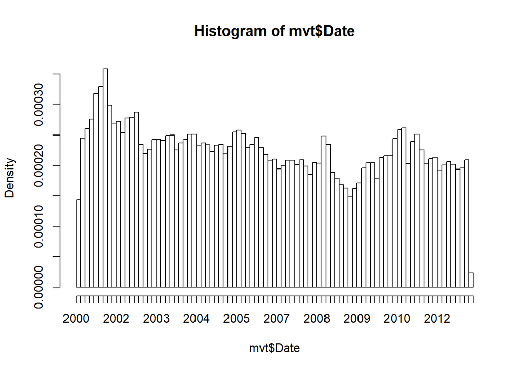

```r
hist(mvt$Date, breaks=100)
```

#### In general, does it look like crime increases or decreases from 2002 - 2012?

While there is not a clear trend, it looks like crime generally decreases.

#### In general, does it look like crime increases or decreases from 2005 - 2008?

In this time period, there is a clear downward trend in crime.

#### In general, does it look like crime increases or decreases from 2009 - 2011?

In this time period, there is a clear upward trend in crime.

Now, lets see how arrests have changed over time by creating a boxplot

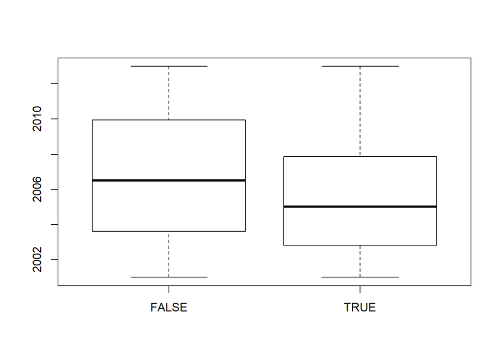

```r
boxplot(mvt$Date ~ mvt$Arrest)
```

#### Does it look like there were more crimes for which arrests were made in the first half of the time period or the second half of the time period?

If you look at the boxplot, the one for Arrest=TRUE is definitely skewed towards the bottom of the plot, meaning that there were more crimes for which arrests were made in the first half of the time period

#### For what proportion of motor vehicle thefts in 2001 was an arrest made?

```r
table(mvt$Arrest, mvt$Year)
```

```
##
##          2001  2002  2003  2004  2005  2006  2007  2008  2009  2010  2011  2012
##   FALSE 18517 16638 14859 15169 14956 14796 13068 13425 11327 14796 15012 13542
##   TRUE   2152  2115  1798  1693  1528  1302  1212  1020   840   701   625   550
```

**Explanation**: If you create a table using the command table(mvt$Arrest, mvt$Year), the column for 2001 has 2152 observations with Arrest=TRUE and 18517 observations with Arrest=FALSE. The fraction of motor vehicle thefts in 2001 for which an arrest was made is thus 2152/(2152+18517) = 0.1041173.

#### For what proportion of motor vehicle thefts in 2007 was an arrest made?

```r
table(mvt$Arrest, mvt$Year)
```

```
##
##          2001  2002  2003  2004  2005  2006  2007  2008  2009  2010  2011  2012
##   FALSE 18517 16638 14859 15169 14956 14796 13068 13425 11327 14796 15012 13542
##   TRUE   2152  2115  1798  1693  1528  1302  1212  1020   840   701   625   550
```

**Explanation**: If you create a table using the command table(mvt$Arrest, mvt$Year), the column for 2007 has 1212 observations with Arrest=TRUE and 13068 observations with Arrest=FALSE. The fraction of motor vehicle thefts in 2007 for which an arrest was made is thus 1212/(1212+13068) = 0.08487395.

#### For what proportion of motor vehicle thefts in 2012 was an arrest made?

```r
table(mvt$Arrest, mvt$Year)
```

```
##
##          2001  2002  2003  2004  2005  2006  2007  2008  2009  2010  2011  2012
##   FALSE 18517 16638 14859 15169 14956 14796 13068 13425 11327 14796 15012 13542
##   TRUE   2152  2115  1798  1693  1528  1302  1212  1020   840   701   625   550
```

**Explanation**: If you create a table using the command table(mvt$Arrest, mvt$Year), the column for 2012 has 550 observations with Arrest=TRUE and 13542 observations with Arrest=FALSE. The fraction of motor vehicle thefts in 2012 for which an arrest was made is thus 550/(550+13542) = 0.03902924.

Since there may still be open investigations for recent crimes, this could explain the trend we are seeing in the data. There could also be other factors at play, and this trend should be investigated further. However, since we don’t know when the arrests were actually made, our detective work in this area has reached a dead end.

### Popular Locations of Interest

We want to find the top five locations where motor vehicle thefts occur. If you create a table of the LocationDescription variable, it is unfortunately very hard to read since there are 78 different locations in the data set. By using the sort function, we can view this same table, but sorted by the number of observations in each category. In your R console, type:

```r
sort(table(mvt$LocationDescription))
```

```
##
##     AIRPORT BUILDING NON-TERMINAL - SECURE AREA                  AIRPORT EXTERIOR - SECURE AREA                                 ANIMAL HOSPITAL
##                                               1                                               1                                               1
##                                 APPLIANCE STORE                                       CTA TRAIN                         JAIL / LOCK-UP FACILITY
##                                               1                                               1                                               1
##                                       NEWSSTAND                                          BRIDGE               COLLEGE/UNIVERSITY RESIDENCE HALL
##                                               1                                               2                                               2
##                               CURRENCY EXCHANGE                                   BOWLING ALLEY                                  CLEANING STORE
##                                               2                                               3                                               3
##                           MEDICAL/DENTAL OFFICE                              ABANDONED BUILDING AIRPORT BUILDING NON-TERMINAL - NON-SECURE AREA
##                                               3                                               4                                               4
##                                      BARBERSHOP                  LAKEFRONT/WATERFRONT/RIVERBANK                                         LIBRARY
##                                               4                                               4                                               4
##                                SAVINGS AND LOAN  AIRPORT TERMINAL UPPER LEVEL - NON-SECURE AREA                                   CHA APARTMENT
##                                               4                                               5                                               5
##                                 DAY CARE CENTER                                    FIRE STATION                                 FOREST PRESERVE
##                                               5                                               5                                               6
##                                            BANK                               CONVENIENCE STORE                                      DRUG STORE
##                                               7                                               7                                               8
##                 OTHER COMMERCIAL TRANSPORTATION                                   ATHLETIC CLUB                   AIRPORT VENDING ESTABLISHMENT
##                                               8                                               9                                              10
##                             AIRPORT PARKING LOT                       SCHOOL, PRIVATE, BUILDING                             TAVERN/LIQUOR STORE
##                                              11                                              14                                              14
##                  FACTORY/MANUFACTURING BUILDING                                   BAR OR TAVERN                                       WAREHOUSE
##                                              16                                              17                                              17
##                             MOVIE HOUSE/THEATER                         RESIDENCE PORCH/HALLWAY                    NURSING HOME/RETIREMENT HOME
##                                              18                                              18                                              21
##                                         TAXICAB                                DEPARTMENT STORE                              HIGHWAY/EXPRESSWAY
##                                              21                                              22                                              22
##                        SCHOOL, PRIVATE, GROUNDS                              VEHICLE-COMMERCIAL              AIRPORT EXTERIOR - NON-SECURE AREA
##                                              23                                              23                                              24
##               OTHER RAILROAD PROP / TRAIN DEPOT                              SMALL RETAIL STORE                               CONSTRUCTION SITE
##                                              28                                              33                                              35
##                                        CAR WASH                      COLLEGE/UNIVERSITY GROUNDS                    GOVERNMENT BUILDING/PROPERTY
##                                              44                                              47                                              48
```

[output cut: 18 more lines]

#### Which locations are the top five locations for motor vehicle thefts, excluding the “Other” category?

These are Street, Parking Lot/Garage (Non. Resid.), Alley, Gas Station, and Driveway - Residential.

Create a subset of the Top5 locations.

```r
Top5 = subset(mvt, LocationDescription=="STREET" | LocationDescription=="PARKING LOT/GARAGE(NON.RESID.)" | LocationDescription=="ALLEY" | LocationDescription=="GAS STATION" | LocationDescription=="DRIVEWAY - RESIDENTIAL")
```

#### One of the locations has a much higher arrest rate than the other locations. Which is it?

To make our tables a bit nicer to read, we can refresh this factor variable. In your R console, type:

```r
Top5$LocationDescription = factor(Top5$LocationDescription)

m = table(Top5$LocationDescription, Top5$Arrest)

prop.table(m,1)
```

```
##
##                                       FALSE       TRUE
##   ALLEY                          0.89211438 0.10788562
##   DRIVEWAY - RESIDENTIAL         0.92119403 0.07880597
##   GAS STATION                    0.79204169 0.20795831
##   PARKING LOT/GARAGE(NON.RESID.) 0.89206841 0.10793159
##   STREET                         0.92594083 0.07405917
```

Gas Station has by far the highest percentage of arrests, with over 20% of motor vehicle thefts resulting in an arrest.

#### On which day of the week do the most motor vehicle thefts at gas stations happen?

```r
m = table(Top5$LocationDescription, Top5$Weekday)

prop.table(m,1)
```

```
##
##                                     Friday    Monday  Saturday    Sunday  Thursday   Tuesday Wednesday
##   ALLEY                          0.1668111 0.1386482 0.1477470 0.1330156 0.1364818 0.1399480 0.1373484
##   DRIVEWAY - RESIDENTIAL         0.1534328 0.1522388 0.1205970 0.1319403 0.1570149 0.1450746 0.1397015
##   GAS STATION                    0.1572714 0.1326386 0.1601137 0.1591663 0.1335860 0.1279015 0.1293226
##   PARKING LOT/GARAGE(NON.RESID.) 0.1569486 0.1432804 0.1480609 0.1303528 0.1401831 0.1395772 0.1415971
##   STREET                         0.1518421 0.1424657 0.1416354 0.1389591 0.1424082 0.1398023 0.1428873
```

Saturday is the day where most motor vehicle thefts at gas stations occur.

#### On which day of the week do the fewest motor vehicle thefts in residential driveways happen?

```r
m = table(Top5$LocationDescription, Top5$Weekday)

prop.table(m,1)
```

```
##
##                                     Friday    Monday  Saturday    Sunday  Thursday   Tuesday Wednesday
##   ALLEY                          0.1668111 0.1386482 0.1477470 0.1330156 0.1364818 0.1399480 0.1373484
##   DRIVEWAY - RESIDENTIAL         0.1534328 0.1522388 0.1205970 0.1319403 0.1570149 0.1450746 0.1397015
##   GAS STATION                    0.1572714 0.1326386 0.1601137 0.1591663 0.1335860 0.1279015 0.1293226
##   PARKING LOT/GARAGE(NON.RESID.) 0.1569486 0.1432804 0.1480609 0.1303528 0.1401831 0.1395772 0.1415971
##   STREET                         0.1518421 0.1424657 0.1416354 0.1389591 0.1424082 0.1398023 0.1428873
```